# Modèle : Classification d'images de chiens et de chats

## Groupe :

- Tristan Nobre
- Clément Zelter
- Erwan Gautier
- Mathieu Andriamiraho

## Présentation du dataset

Le dataset **Dogs & Cats Images** contient des images d'animaux classées en deux catégories :

- **Chien** 🐶
- **Chat** 🐱

## Choix du modèle

Pour cette tâche de classification, un **réseau de neurones convolutionnel (CNN)** est le plus adapté.

### Pourquoi un CNN ?

Contrairement à un **réseau de neurones dense (MLP)**, qui traite chaque pixel indépendamment sans tenir compte des relations spatiales, un CNN est conçu pour **analyser les images** en capturant les **motifs visuels** et les **relations spatiales** entre les pixels.

Un CNN apprend progressivement à détecter :

1. **Les bords et contours** aux premières couches.
2. **Les textures et motifs plus complexes** aux couches intermédiaires.
3. **Les formes spécifiques des objets** dans les couches les plus profondes.

Grâce à cette hiérarchie d'apprentissage, le modèle est capable de différencier efficacement **chats et chiens** en fonction de leurs caractéristiques visuelles.

Le dataset Dogs & Cats Images contient des images d'animaux réparties en deux catégories :

- chien
- chat

Un réseau de neurones convolutionnel (CNN) est le choix le plus adapté pour ce type de tâche, car il est conçu pour analyser les images en capturant les motifs visuels et les relations spatiales entre les pixels. Contrairement à un réseau de neurones dense (MLP), qui traite chaque pixel indépendamment et ne peut pas exploiter la structure de l’image, un CNN apprend à détecter des bords, des textures et des formes complexes à différents niveaux de profondeur, ce qui est essentiel pour différencier des animaux.

```python
import numpy as np
import keras
from keras import layers
from tensorflow import data as tf_data
import matplotlib.pyplot as plt
import seaborn as sns
from sklearn.metrics import confusion_matrix, classification_report
```

## Chargement du Dataset Dogs & Cats

Nous chargeons les images depuis le répertoire d'entraînement en les redimensionnant à **180x180 pixels**.  
Les images sont traitées par **batchs de 128** pour optimiser l'entraînement.  
Une partie des données (**20%**) est réservée pour la validation afin d'évaluer la performance du modèle.

```python
image_size = (180, 180)
batch_size = 128

train_ds, val_ds = keras.utils.image_dataset_from_directory(
    "dataset/training_set",
    validation_split=0.2,
    subset="both",
    seed=1337,
    image_size=image_size,
    batch_size=batch_size,
)
```

## Visualisation d'un échantillon d'images

Affichage de **9 images aléatoires** issues du dataset d'entraînement.  
Chaque image est accompagnée de son **label** (0 = Chat, 1 = Chien).  
Cette visualisation permet de vérifier la qualité des images et des annotations avant l'entraînement du modèle.

```
2025-02-14 15:34:30.133384: I tensorflow/core/framework/local_rendezvous.cc:405] Local rendezvous is aborting with status: OUT_OF_RANGE: End of sequence
```

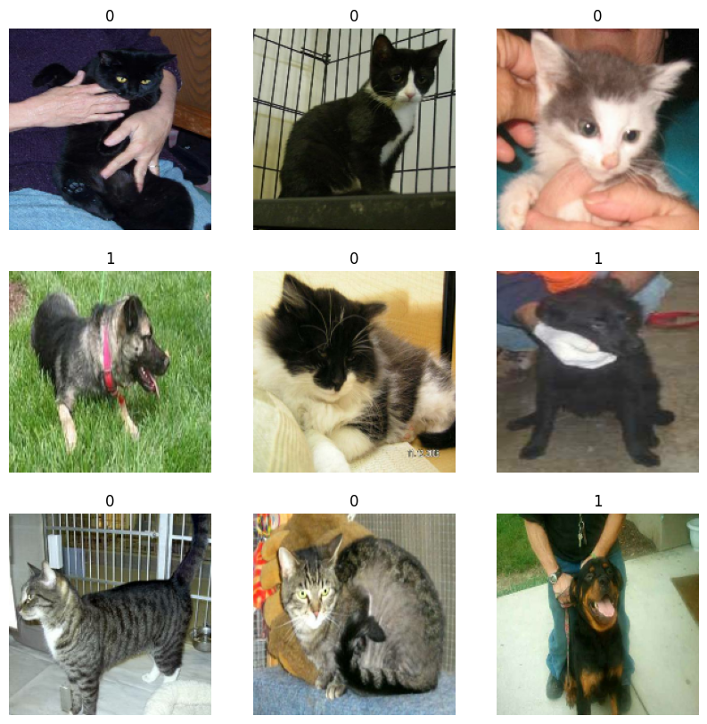

```python
plt.figure(figsize=(10, 10))
for images, labels in train_ds.take(1):
    for i in range(9):
        ax = plt.subplot(3, 3, i + 1)
        plt.imshow(np.array(images[i]).astype("uint8"))
        plt.title(int(labels[i]))
        plt.axis("off")
```

## Augmentation des données

Pour améliorer la **généralisation** du modèle et éviter l'overfitting, nous appliquons une augmentation des images.  
Les transformations utilisées sont :

- **Flip horizontal** : retourne l'image horizontalement de manière aléatoire.
- **Rotation aléatoire (10%)** : tourne légèrement l'image pour simuler des variations naturelles.

Ces transformations sont appliquées aux images d'entraînement pour enrichir le dataset sans collecter de nouvelles données.

```python
data_augmentation_layers = [
    layers.RandomFlip("horizontal"),
    layers.RandomRotation(0.1),
]


def data_augmentation(images):
    for layer in data_augmentation_layers:
        images = layer(images)
    return images
```

## Visualisation des images augmentées

Affichage de **9 images transformées** par la fonction d'**augmentation des données**.  
Chaque image est modifiée aléatoirement (flip horizontal, rotation) pour observer l'effet des transformations.  
Cela permet de vérifier que l'augmentation améliore la diversité des données sans dégrader la qualité des images.

```
2025-02-14 15:34:30.663641: I tensorflow/core/framework/local_rendezvous.cc:405] Local rendezvous is aborting with status: OUT_OF_RANGE: End of sequence
```

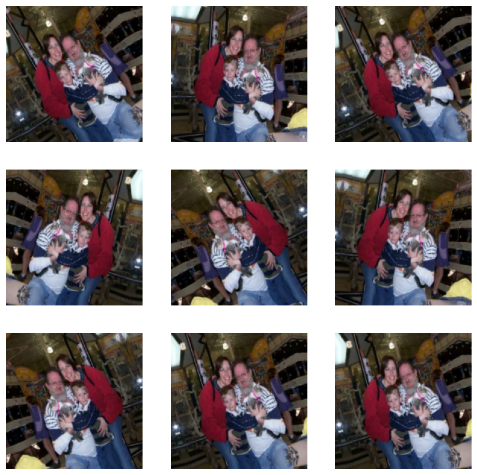

```python
plt.figure(figsize=(10, 10))
for images, _ in train_ds.take(1):
    for i in range(9):
        augmented_images = data_augmentation(images)
        ax = plt.subplot(3, 3, i + 1)
        plt.imshow(np.array(augmented_images[0]).astype("uint8"))
        plt.axis("off")
```

## Application de l'augmentation et optimisation des performances

- **Augmentation des données** : Appliquée aux images du dataset d'entraînement avant leur passage dans le modèle.
- **Optimisation avec Prefetching** :
  - Permet de **charger les données en mémoire GPU** pendant que le modèle effectue ses calculs.
  - Améliore l'**efficacité du pipeline** en réduisant le temps d'attente entre les batchs.
  - Appliqué à **train_ds** et **val_ds** pour un entraînement plus fluide et rapide.

```python
train_ds = train_ds.map(
    lambda img, label: (data_augmentation(img), label),
    num_parallel_calls=tf_data.AUTOTUNE,
)

train_ds = train_ds.prefetch(tf_data.AUTOTUNE)
val_ds = val_ds.prefetch(tf_data.AUTOTUNE)
```

## Construction du modèle de classification

Ce modèle de **réseau de neurones convolutionnel (CNN)** est conçu pour classer les images en **chats** ou **chiens**.  
Il suit une architecture inspirée de **Xception**, avec des **couches résiduelles** et des **convolutions séparables**.

### **Structure du modèle :**

- **Normalisation des pixels** : Les valeurs des pixels sont mises à l'échelle entre 0 et 1.
- **Blocs convolutifs** :
  - Une première couche **Conv2D** avec 128 filtres.
  - Plusieurs blocs avec des convolutions **Séparables** (256 → 512 → 728 filtres).
  - **Batch Normalization** et **ReLU** pour accélérer l'entraînement.
  - **MaxPooling** et **connexion résiduelle** pour améliorer la profondeur du réseau.
- **Dernières couches** :
  - Une **convolution finale** avec 1024 filtres.
  - Une **couche de Global Average Pooling** pour compresser l'information.
  - Une **couche Dropout (0.25)** pour éviter le surapprentissage.
  - Une **couche dense** sans activation, produisant des **logits** pour la classification binaire.

Enfin, le modèle est **affiché** avec `model.summary()` pour visualiser sa structure et son nombre de paramètres.

```python
def make_model(input_shape, num_classes):
    inputs = keras.Input(shape=input_shape)

    # Entry block
    x = layers.Rescaling(1.0 / 255)(inputs)
    x = layers.Conv2D(128, 3, strides=2, padding="same")(x)
    x = layers.BatchNormalization()(x)
    x = layers.Activation("relu")(x)

    previous_block_activation = x  # Set aside residual

    for size in [256, 512, 728]:
        x = layers.Activation("relu")(x)
        x = layers.SeparableConv2D(size, 3, padding="same")(x)
        x = layers.BatchNormalization()(x)

        x = layers.Activation("relu")(x)
        x = layers.SeparableConv2D(size, 3, padding="same")(x)
        x = layers.BatchNormalization()(x)

        x = layers.MaxPooling2D(3, strides=2, padding="same")(x)

        # Project residual
        residual = layers.Conv2D(size, 1, strides=2, padding="same")(
            previous_block_activation
        )
        x = layers.add([x, residual])  # Add back residual
        previous_block_activation = x  # Set aside next residual

    x = layers.SeparableConv2D(1024, 3, padding="same")(x)
    x = layers.BatchNormalization()(x)
    x = layers.Activation("relu")(x)

    x = layers.GlobalAveragePooling2D()(x)
    if num_classes == 2:
        units = 1
    else:
        units = num_classes

    x = layers.Dropout(0.25)(x)
    # We specify activation=None so as to return logits
    outputs = layers.Dense(units, activation=None)(x)
    return keras.Model(inputs, outputs)


model = make_model(input_shape=image_size + (3,), num_classes=2)
# keras.utils.plot_model(model, show_shapes=True)
model.summary()
```

```
Model: "functional"
```

```
┏━━━━━━━━━━━━━━━━━━━━━┳━━━━━━━━━━━━━━━━━━━┳━━━━━━━━━━━━┳━━━━━━━━━━━━━━━━━━━┓
┃ Layer (type)        ┃ Output Shape      ┃    Param # ┃ Connected to      ┃
┡━━━━━━━━━━━━━━━━━━━━━╇━━━━━━━━━━━━━━━━━━━╇━━━━━━━━━━━━╇━━━━━━━━━━━━━━━━━━━┩
│ input_layer         │ (None, 180, 180,  │          0 │ -                 │
│ (InputLayer)        │ 3)                │            │                   │
├─────────────────────┼───────────────────┼────────────┼───────────────────┤
│ rescaling           │ (None, 180, 180,  │          0 │ input_layer[0][0] │
│ (Rescaling)         │ 3)                │            │                   │
├─────────────────────┼───────────────────┼────────────┼───────────────────┤
│ conv2d (Conv2D)     │ (None, 90, 90,    │      3,584 │ rescaling[0][0]   │
│                     │ 128)              │            │                   │
├─────────────────────┼───────────────────┼────────────┼───────────────────┤
│ batch_normalization │ (None, 90, 90,    │        512 │ conv2d[0][0]      │
│ (BatchNormalizatio… │ 128)              │            │                   │
├─────────────────────┼───────────────────┼────────────┼───────────────────┤
│ activation          │ (None, 90, 90,    │          0 │ batch_normalizat… │
│ (Activation)        │ 128)              │            │                   │
├─────────────────────┼───────────────────┼────────────┼───────────────────┤
│ activation_1        │ (None, 90, 90,    │          0 │ activation[0][0]  │
│ (Activation)        │ 128)              │            │                   │
├─────────────────────┼───────────────────┼────────────┼───────────────────┤
│ separable_conv2d    │ (None, 90, 90,    │     34,176 │ activation_1[0][… │
│ (SeparableConv2D)   │ 256)              │            │                   │
├─────────────────────┼───────────────────┼────────────┼───────────────────┤
│ batch_normalizatio… │ (None, 90, 90,    │      1,024 │ separable_conv2d… │
│ (BatchNormalizatio… │ 256)              │            │                   │
├─────────────────────┼───────────────────┼────────────┼───────────────────┤
│ activation_2        │ (None, 90, 90,    │          0 │ batch_normalizat… │
│ (Activation)        │ 256)              │            │                   │
├─────────────────────┼───────────────────┼────────────┼───────────────────┤
│ separable_conv2d_1  │ (None, 90, 90,    │     68,096 │ activation_2[0][… │
│ (SeparableConv2D)   │ 256)              │            │                   │
├─────────────────────┼───────────────────┼────────────┼───────────────────┤
│ batch_normalizatio… │ (None, 90, 90,    │      1,024 │ separable_conv2d… │
│ (BatchNormalizatio… │ 256)              │            │                   │
├─────────────────────┼───────────────────┼────────────┼───────────────────┤
│ max_pooling2d       │ (None, 45, 45,    │          0 │ batch_normalizat… │
│ (MaxPooling2D)      │ 256)              │            │                   │
├─────────────────────┼───────────────────┼────────────┼───────────────────┤
│ conv2d_1 (Conv2D)   │ (None, 45, 45,    │     33,024 │ activation[0][0]  │
```

[output cut: 60 more lines]

```
│ (SeparableConv2D)   │ 1024)             │            │                   │
├─────────────────────┼───────────────────┼────────────┼───────────────────┤
│ batch_normalizatio… │ (None, 12, 12,    │      4,096 │ separable_conv2d… │
│ (BatchNormalizatio… │ 1024)             │            │                   │
├─────────────────────┼───────────────────┼────────────┼───────────────────┤
│ activation_7        │ (None, 12, 12,    │          0 │ batch_normalizat… │
│ (Activation)        │ 1024)             │            │                   │
├─────────────────────┼───────────────────┼────────────┼───────────────────┤
│ global_average_poo… │ (None, 1024)      │          0 │ activation_7[0][… │
│ (GlobalAveragePool… │                   │            │                   │
├─────────────────────┼───────────────────┼────────────┼───────────────────┤
│ dropout (Dropout)   │ (None, 1024)      │          0 │ global_average_p… │
├─────────────────────┼───────────────────┼────────────┼───────────────────┤
│ dense (Dense)       │ (None, 1)         │      1,025 │ dropout[0][0]     │
└─────────────────────┴───────────────────┴────────────┴───────────────────┘
```

```
 Total params: 2,731,065 (10.42 MB)
```

```
 Trainable params: 2,722,777 (10.39 MB)
```

```
 Non-trainable params: 8,288 (32.38 KB)
```

## Entraînement du modèle

L'entraînement est effectué sur **25 époques** avec les paramètres suivants :

### **Configuration :**

- **Optimiseur : Adam (taux d'apprentissage = 3e-4)**
  - Permet une mise à jour adaptative des poids pour un entraînement stable.
- **Fonction de perte : Binary Crossentropy (avec logits)**
  - Convient aux problèmes de classification binaire (chats vs chiens).
- **Métrique suivie : Binary Accuracy**
  - Indique la proportion de bonnes prédictions effectuées par le modèle.

### **Callbacks :**

- **ModelCheckpoint**
  - Sauvegarde automatique du modèle à chaque époque (`save_at_{epoch}.keras`).
  - Permet de reprendre l'entraînement ou de tester différentes versions du modèle.

Le modèle est entraîné sur les **données augmentées** et évalué sur l'ensemble de validation pour suivre son évolution.

```python
epochs = 25

callbacks = [
    keras.callbacks.ModelCheckpoint("save_at_{epoch}.keras"),
]
model.compile(
    optimizer=keras.optimizers.Adam(3e-4),
    loss=keras.losses.BinaryCrossentropy(from_logits=True),
    metrics=[keras.metrics.BinaryAccuracy(name="acc")],
)
model.fit(
    train_ds,
    epochs=epochs,
    callbacks=callbacks,
    validation_data=val_ds,
)
```

```
50/50 ━━━━━━━━━━━━━━━━━━━━ 491s 10s/step - acc: 0.5731 - loss: 0.6975 - val_acc: 0.5025 - val_loss: 0.6933
50/50 ━━━━━━━━━━━━━━━━━━━━ 482s 10s/step - acc: 0.6553 - loss: 0.6057 - val_acc: 0.5025 - val_loss: 0.6939
50/50 ━━━━━━━━━━━━━━━━━━━━ 479s 10s/step - acc: 0.6990 - loss: 0.5474 - val_acc: 0.5025 - val_loss: 0.6941
50/50 ━━━━━━━━━━━━━━━━━━━━ 482s 10s/step - acc: 0.7457 - loss: 0.4908 - val_acc: 0.5025 - val_loss: 0.6933
50/50 ━━━━━━━━━━━━━━━━━━━━ 472s 9s/step - acc: 0.7625 - loss: 0.4662 - val_acc: 0.5025 - val_loss: 0.6980
50/50 ━━━━━━━━━━━━━━━━━━━━ 505s 10s/step - acc: 0.7834 - loss: 0.4307 - val_acc: 0.5025 - val_loss: 0.7174
50/50 ━━━━━━━━━━━━━━━━━━━━ 539s 11s/step - acc: 0.8030 - loss: 0.3945 - val_acc: 0.4975 - val_loss: 0.7918
50/50 ━━━━━━━━━━━━━━━━━━━━ 527s 11s/step - acc: 0.8287 - loss: 0.3672 - val_acc: 0.4975 - val_loss: 0.8382
50/50 ━━━━━━━━━━━━━━━━━━━━ 529s 11s/step - acc: 0.8475 - loss: 0.3214 - val_acc: 0.4975 - val_loss: 0.8473
50/50 ━━━━━━━━━━━━━━━━━━━━ 530s 11s/step - acc: 0.8560 - loss: 0.3019 - val_acc: 0.5106 - val_loss: 0.7586
50/50 ━━━━━━━━━━━━━━━━━━━━ 533s 11s/step - acc: 0.8612 - loss: 0.3045 - val_acc: 0.5456 - val_loss: 0.7064
50/50 ━━━━━━━━━━━━━━━━━━━━ 518s 10s/step - acc: 0.8729 - loss: 0.2815 - val_acc: 0.5412 - val_loss: 0.7060
50/50 ━━━━━━━━━━━━━━━━━━━━ 513s 10s/step - acc: 0.8766 - loss: 0.2657 - val_acc: 0.5294 - val_loss: 0.8446
50/50 ━━━━━━━━━━━━━━━━━━━━ 515s 10s/step - acc: 0.8937 - loss: 0.2416 - val_acc: 0.5456 - val_loss: 1.0351
50/50 ━━━━━━━━━━━━━━━━━━━━ 516s 10s/step - acc: 0.8902 - loss: 0.2298 - val_acc: 0.6744 - val_loss: 0.5648
50/50 ━━━━━━━━━━━━━━━━━━━━ 511s 10s/step - acc: 0.9116 - loss: 0.2056 - val_acc: 0.8462 - val_loss: 0.2910
50/50 ━━━━━━━━━━━━━━━━━━━━ 515s 10s/step - acc: 0.9085 - loss: 0.2122 - val_acc: 0.8719 - val_loss: 0.2784
50/50 ━━━━━━━━━━━━━━━━━━━━ 518s 10s/step - acc: 0.9177 - loss: 0.1882 - val_acc: 0.7944 - val_loss: 0.4256
50/50 ━━━━━━━━━━━━━━━━━━━━ 513s 10s/step - acc: 0.9188 - loss: 0.1818 - val_acc: 0.6606 - val_loss: 0.6632
50/50 ━━━━━━━━━━━━━━━━━━━━ 513s 10s/step - acc: 0.9313 - loss: 0.1621 - val_acc: 0.8706 - val_loss: 0.2587
50/50 ━━━━━━━━━━━━━━━━━━━━ 519s 10s/step - acc: 0.9286 - loss: 0.1564 - val_acc: 0.7194 - val_loss: 0.6311
50/50 ━━━━━━━━━━━━━━━━━━━━ 528s 11s/step - acc: 0.9408 - loss: 0.1396 - val_acc: 0.7850 - val_loss: 0.4448
50/50 ━━━━━━━━━━━━━━━━━━━━ 527s 11s/step - acc: 0.9402 - loss: 0.1322 - val_acc: 0.9075 - val_loss: 0.2636
50/50 ━━━━━━━━━━━━━━━━━━━━ 526s 11s/step - acc: 0.9378 - loss: 0.1468 - val_acc: 0.7694 - val_loss: 0.4908
50/50 ━━━━━━━━━━━━━━━━━━━━ 522s 10s/step - acc: 0.9476 - loss: 0.1241 - val_acc: 0.9087 - val_loss: 0.2556
```

```
<keras.src.callbacks.history.History at 0x177a4e660>
```

## Test du modèle sur une image individuelle

Nous chargeons une **image de test** pour évaluer les prédictions du modèle.

### **Étapes :**

1. **Chargement et affichage de l'image**
   - L'image est redimensionnée à la taille d'entrée du modèle (**180x180 pixels**).
2. **Prétraitement de l'image**
   - Conversion en tableau numérique (`img_to_array`).
   - Ajout d'une dimension pour correspondre au format attendu par le modèle (`expand_dims`).
3. **Prédiction du modèle**
   - Passage de l'image dans le réseau pour obtenir un score de classification.
   - Application d'une **fonction sigmoïde** pour transformer le score en probabilité.
4. **Interprétation du résultat**
   - Affichage du pourcentage de confiance du modèle pour **chat** et **chien**.

L'objectif est de vérifier si le modèle classifie correctement l'image fournie.

```
1/1 ━━━━━━━━━━━━━━━━━━━━ 0s 40ms/step
This image is 0.00% cat and 100.00% dog.
```

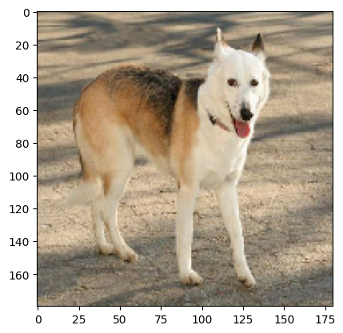

```python
img = keras.utils.load_img("dataset/test_set/dogs/dog.4518.jpg", target_size=image_size)
plt.imshow(img)

img_array = keras.utils.img_to_array(img)
img_array = keras.ops.expand_dims(img_array, 0)  # Create batch axis

predictions = model.predict(img_array)
score = float(keras.ops.sigmoid(predictions[0][0]))
print(f"This image is {100 * (1 - score):.2f}% cat and {100 * score:.2f}% dog.")
```

## Évaluation du modèle sur l'ensemble de test

Nous testons les performances du modèle sur l'ensemble de test (`test_set`) en suivant plusieurs étapes :

### **1. Chargement et évaluation du dataset**

- Chargement des **images de test** avec la même configuration que l'entraînement.
- Évaluation du modèle pour obtenir la **perte** et l'**accuracy globale**.
- Sauvegarde du modèle entraîné (`model.keras`) pour une utilisation future.

### **2. Prédictions sur l'ensemble de test**

- Passage des images dans le modèle pour obtenir des **prédictions brutes**.
- Application d'un **seuil** pour classer les images en **chat (0) ou chien (1)**.
- Stockage des **prédictions** et des **valeurs réelles** pour l'analyse.

### **3. Analyse des performances**

- **Matrice de confusion**
  - Permet de visualiser les **erreurs de classification** (faux positifs/négatifs).
  - Utilisation d'un **heatmap** pour une meilleure interprétation.
- **Rapport de classification**
  - Fournit les métriques **précision, rappel et F1-score** pour chaque classe.
  - Indique la qualité du modèle sur **les deux catégories (chats et chiens)**.

Ces résultats permettent de mieux comprendre la capacité du modèle à **généraliser** sur des images non vues.

```
Found 2000 files belonging to 2 classes.
16/16 ━━━━━━━━━━━━━━━━━━━━ 28s 2s/step - acc: 0.9191 - loss: 0.2273
4/4 ━━━━━━━━━━━━━━━━━━━━ 2s 434ms/step
4/4 ━━━━━━━━━━━━━━━━━━━━ 2s 438ms/step
4/4 ━━━━━━━━━━━━━━━━━━━━ 2s 417ms/step
4/4 ━━━━━━━━━━━━━━━━━━━━ 2s 417ms/step
4/4 ━━━━━━━━━━━━━━━━━━━━ 2s 421ms/step
4/4 ━━━━━━━━━━━━━━━━━━━━ 2s 419ms/step
4/4 ━━━━━━━━━━━━━━━━━━━━ 2s 421ms/step
4/4 ━━━━━━━━━━━━━━━━━━━━ 2s 433ms/step
4/4 ━━━━━━━━━━━━━━━━━━━━ 2s 429ms/step
4/4 ━━━━━━━━━━━━━━━━━━━━ 2s 427ms/step
4/4 ━━━━━━━━━━━━━━━━━━━━ 2s 428ms/step
4/4 ━━━━━━━━━━━━━━━━━━━━ 2s 428ms/step
4/4 ━━━━━━━━━━━━━━━━━━━━ 2s 437ms/step
4/4 ━━━━━━━━━━━━━━━━━━━━ 2s 457ms/step
4/4 ━━━━━━━━━━━━━━━━━━━━ 2s 431ms/step
3/3 ━━━━━━━━━━━━━━━━━━━━ 1s 342ms/step
```

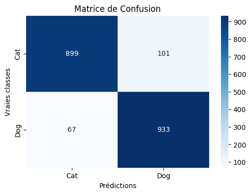

```
              precision    recall  f1-score   support

         Cat       0.93      0.90      0.91      1000
         Dog       0.90      0.93      0.92      1000

    accuracy                           0.92      2000
   macro avg       0.92      0.92      0.92      2000
weighted avg       0.92      0.92      0.92      2000
```

```python
test_ds = keras.utils.image_dataset_from_directory(
    "dataset/test_set", image_size=image_size, batch_size=batch_size
)

model.evaluate(test_ds)
model.save("model.keras")

# Obtenir les vraies classes
y_true = []
y_pred = []

for images, labels in test_ds:
    preds = model.predict(images)  # Prédictions brutes
    preds = (preds > 0).astype(int).flatten()  # Seuil pour classer en 0 (chat) ou 1 (chien)

    y_true.extend(labels.numpy())  # Ajouter les vraies classes
    y_pred.extend(preds)  # Ajouter les prédictions

y_true = np.array(y_true)
y_pred = np.array(y_pred)

# Afficher la matrice de confusion
cm = confusion_matrix(y_true, y_pred)
plt.figure(figsize=(6, 4))
sns.heatmap(cm, annot=True, fmt="d", cmap="Blues", xticklabels=["Cat", "Dog"], yticklabels=["Cat", "Dog"])
plt.xlabel("Prédictions")
plt.ylabel("Vraies classes")
plt.title("Matrice de Confusion")
plt.show()

# Afficher le rapport de classification
print(classification_report(y_true, y_pred, target_names=["Cat", "Dog"]))
```

## Conclusion des performances du modèle

### **1. Analyse de la matrice de confusion**

- **899 chats** correctement classifiés, mais **101 chats** mal classés comme chiens.
- **933 chiens** correctement classifiés, avec **67 erreurs** les confondant avec des chats.
- Les erreurs sont légèrement plus fréquentes pour les chats que pour les chiens.

### **2. Analyse des métriques**

- **Précision** :
  - **0.93 pour les chats** → 93% des prédictions de "chat" sont correctes.
  - **0.90 pour les chiens** → 90% des prédictions de "chien" sont correctes.
- **Rappel** :
  - **0.90 pour les chats** → 90% des vrais chats sont bien détectés.
  - **0.93 pour les chiens** → 93% des vrais chiens sont bien détectés.
- **F1-score global de 0.92** → Le modèle atteint un bon équilibre entre précision et rappel.

### **3. Conclusion générale**

- Avec une **accuracy globale de 92%**, le modèle montre de **bonnes performances**.
- Il est **plus performant pour reconnaître les chiens** que les chats, bien que la différence soit faible.
- L'amélioration pourrait passer par :
  - **Plus de diversité dans les données d'entraînement**.
  - **Un affinage du modèle** (ajustement du learning rate, augmentation de données plus variée).
  - **Un équilibrage des classes** si les données contiennent des biais.

Globalement, ce modèle est fiable pour une **classification binaire entre chiens et chats** avec un **faible taux d'erreur**.